# MA331-Coursework

Text analytics of the TED talks by Dan Gilbert and John Hodgman

2112224-Ronak-Chudasama

# Introduction

Aim of this report is to compare word frequencies and perform sentiment analyses on the transcripts of two Ted talkers. Following are the details of Ted talkers I am assigned to:

#### 1.Dan Gilbert :

Dan Gilbert is Harvard Psychologist also known as happiness expert[1]. His 2 talks are included in the data sets:

*The psychology of your future self* - This talk was given in March 2014.It is about how we wrongly assume our future self based on our present self.

*The surprising science of happiness* - It is talk from Feb 2004.It speaks about concept of how our psychological immune system react to term happiness.

#### 2.John Hodgman :

John Hodgman is a humourist, geek celebrity, former professional literary agent. He is also a write and known as an expert on all world knowledge[1].2 talks of his are included in data set

*Aliens, love – where are they?* - It was given in Feb 2008. It talks about topics like Alien, physics and then how it was related to his love life.

*Design, explained.* - It was given in Mar 2012. He explains design of 3 modern objects.

# Methods

### 1. Description:

Data set has 4 rows (4 transcript of authors) and 5 columns(talk_id, headline, text, speaker and views). .

### 2. Cleaning data

As task is to deal with words, numbers need to be deleted .I have deleted the numbers using *stringr* package.

### 3. Extracting words

Then I have used *unnest_tokens* function to extract words from the text.

| talk_id | headline | speaker | views | word |
| --- | --- | --- | --- | --- |
| 97 | The surprising science of happiness | Dan Gilbert | 15685502 | when |
| 97 | The surprising science of happiness | Dan Gilbert | 15685502 | you |
| 97 | The surprising science of happiness | Dan Gilbert | 15685502 | have |
| 97 | The surprising science of happiness | Dan Gilbert | 15685502 | minutes |
| 97 | The surprising science of happiness | Dan Gilbert | 15685502 | to |

### 4.Identifying top words

Here first I am finding all top words from the transcripts. Table below shows top 6 words used in talk. As expected these are the stop words because we normally use more stop words in our day to day life. So these needs to be filtered. I am using *get_stopwords()* function to filter these stops words.

| word | n |
| --- | --- |
| the | 383 |
| and | 269 |
| to | 260 |
| of | 193 |
| a | 171 |
| i | 156 |

| word | n |
| --- | --- |
| one | 60 |
| laughter | 39 |
| people | 39 |
| now | 36 |
| us | 35 |
| like | 30 |

After filtering stop words, above table shows top 6 words used in talks.

### 4.Comparing speaker’s vocabularies

Next task is to compare vocabularies of both speakers.

| word | Dan Gilbert | John Hodgman |
| --- | --- | --- |
| asked | 9 | 5 |
| back | 6 | 10 |
| better | 11 | 2 |
| can | 20 | 5 |
| change | 27 | 0 |
| come | 6 | 9 |

### 5. Sentiment Analysis

Sentiment analysis is used to assign sentiment to each word. This sentiments are anger, fear or surprise.It helps to understand emotions for machine. In this project, I have used nrc lexicon from the *textdata* package.

| sentiment | Dan Gilbert | John Hodgman |
| --- | --- | --- |
| anger | 55 | 25 |
| anticipation | 166 | 117 |
| disgust | 36 | 27 |
| fear | 70 | 54 |
| joy | 149 | 101 |
| negative | 107 | 94 |

Above table displays word count per sentiment used in both talks. Dan Gilbert has used more words in his talk. Emotions like anticipation, joy, negative are used more often in talks.

# Results

### 1.Top words Visualization

Graph shows top 6 words used in the talks having *one* has mostly used word.

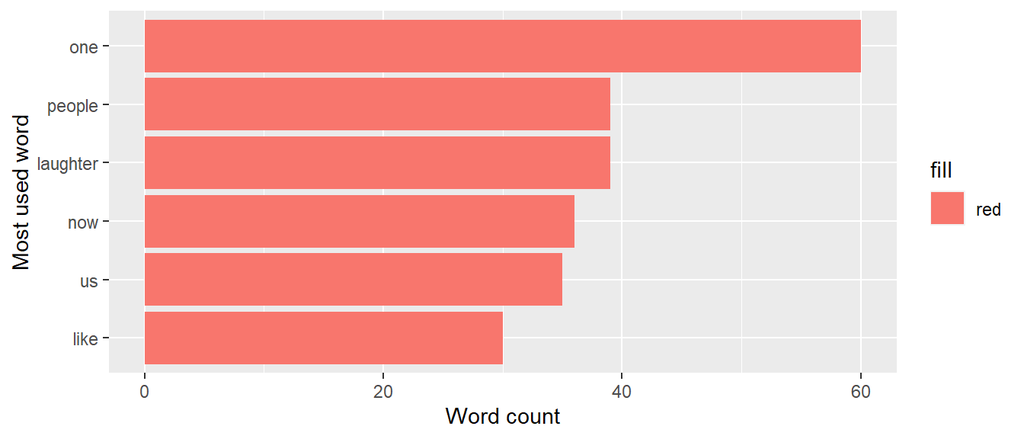

## 2.Vocabulary Comparison Visualization

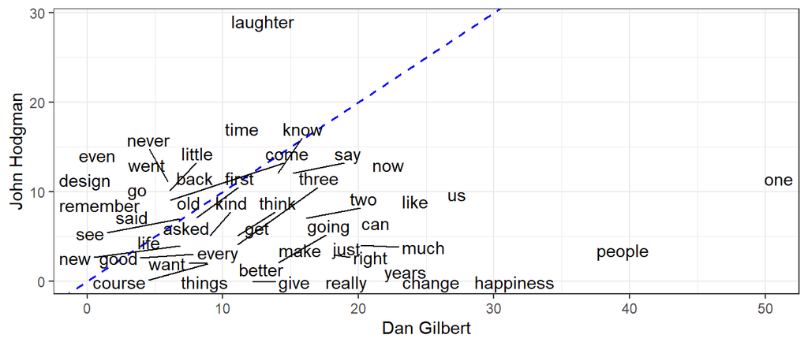

Above graph shows representation of most words used by both speakers. There are words like new, first, said which are equally used by both of them.

### 3.Sentiment Analysis Visualization

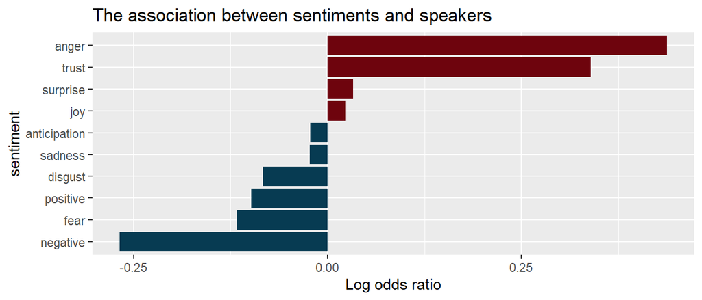

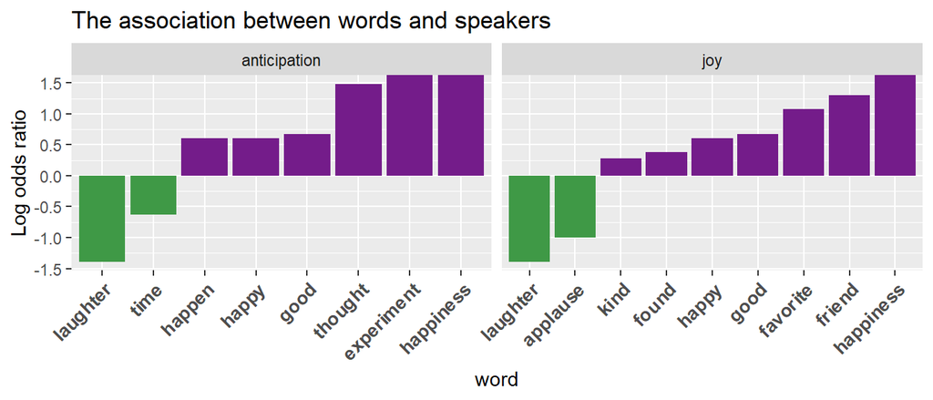

# Discussion :

```
Important challenge I faced working on this task is that there are 2 different authors with having transcripts of 4 different topics and length.
```

Following is the summary of this project:

[output not shown]

*Limitations:*

```
 As ted talks are filled with sarcasm, I think this will be the biggest limitation that project could not identify sarcasm involved in the talks. This can be worked on in future study.
```

# References :

[1] - *https://www.ted.com/*

[2] - *http://data-science.essex.ac.uk:3838/MA331/W7/*

[3] - *http://data-science.essex.ac.uk:3838/MA331/W8/*

[4] - *https://monkeylearn.com/sentiment-analysis/*

[5] - *http://data-science.essex.ac.uk:3838/MA331/W9/*